# Text Analytics Final Project

## HOYA 8: Taylor Whitelow

### 08 October 2023

#### You are leading a new branded hotel and you need to know what customers who give poor reviews of hotels tend to bring up. To minimize poor service, your analytics team will examine hotel reviews using topic modeling to identify what reviewers who give poor reviews actually write about in their experience to ensure your hotel focuses special attention and ensures high-quality services in those domains.

#### You will use the Yelp hotel reviews data to build a presentation to present to technical and non-technical co-workers and managers. The presentation should be professional and succinct (about 12 minutes) and focus on the problem at hand including:

- #### What topics do reviewers tend to bring up in general?
- #### How do happy customers differ from unhappy customers in the topics they bring up in their review?
- #### Are there other characteristics about customers that would be useful to know about?
- #### Based on the results and what should your new hotel focus on?
- #### What are the main takeaways and recommendations?

#### You will deliver the results as a professional, team-based presentation. You should discuss the background of the problem, any important processing and modeling steps you made to arrive at your results, the key results and insights, and a set of recommendations moving forward. Your presentation should be 10 minutes and recorded. You will submit two files: (1) the recorded presentation; and (2) the code you used for your analysis.

```python
#Import Packages
from nltk.tokenize import word_tokenize
from gensim.corpora.dictionary import Dictionary
from gensim.models import LdaModel
import pandas as pd
import numpy as np
import altair as alt
import nltk

from nltk.corpus import stopwords
from nltk.tokenize import word_tokenize
from gensim.models import CoherenceModel
import pyLDAvis
import pyLDAvis.gensim_models as gensim_pyvis
import warnings
from wordcloud import WordCloud, STOPWORDS
import matplotlib.pyplot as plt
warnings.filterwarnings("ignore")
```

#### Step 1 - Ingest Data

```python
#Ingest data
df = pd.read_csv("hotel_final.csv")
df_pos = df[df["rating"] >= 4]
df_neg = df[df["rating"] <= 2]
```

#### Step 2 - Clean and Process Text

```python
#Function to remove punctuation and convert to lower case
def clean_text(t):
    import re

    t = t.lower()
    t = re.sub("[()!?]", "", t)        #remove punctuation
    t = re.sub("\[.*?\]", "", t)       #remove puncutation
    t = re.sub("[^a-z]", " ", t)       #remove anything that is not a letter
    return t
```

```python
#Convert reviewContent column to string
df["reviewContent"] = df["reviewContent"].astype("string")

#Apply clean_text function to reviewContent column
df["text_clean"] = df["reviewContent"].apply(clean_text)

#Convert reviewContent column to string
df_pos["reviewContent"] = df_pos["reviewContent"].astype("string")

#Apply clean_text function to reviewContent column
df_pos["text_clean"] = df_pos["reviewContent"].apply(clean_text)

#Convert reviewContent column to string
df_neg["reviewContent"] = df_neg["reviewContent"].astype("string")

#Apply clean_text function to reviewContent column
df_neg["text_clean"] = df_neg["reviewContent"].apply(clean_text)
```

```python
#Convert reviewContent column to string
df["reviewContent"] = df["reviewContent"].astype("string")
df_pos["reviewContent"] = df_pos["reviewContent"].astype("string")
df_neg["reviewContent"] = df_neg["reviewContent"].astype("string")

#Apply clean_text function to reviewContent column
df["text_clean"] = df["reviewContent"].apply(clean_text)
df_pos["text_clean"] = df_pos["reviewContent"].apply(clean_text)
df_neg["text_clean"] = df_neg["reviewContent"].apply(clean_text)
```

```python
#Remove stopwords

#Import and read in stopwords
sw = stopwords.words("english")

#Add additional stopwords to stopword list
sw.extend(["hotel", "stay", "stayed", "room"])

#Filter out stopwords and save result in text_clean
df['text_clean'] = df['text_clean'].apply(lambda each: ' '.join([each for each in each.split() if each not in (sw)]))
df_pos['text_clean'] = df_pos['text_clean'].apply(lambda each: ' '.join([each for each in each.split() if each not in (sw)]))
df_neg['text_clean'] = df_neg['text_clean'].apply(lambda each: ' '.join([each for each in each.split() if each not in (sw)]))
```

```python
# Tokenize reviewContent column
df["text_tokenized"] = df["text_clean"].apply(word_tokenize)
df_pos["text_tokenized"] = df_pos["text_clean"].apply(word_tokenize)
df_neg["text_tokenized"] = df_neg["text_clean"].apply(word_tokenize)
```

#### EDA

```python
 #Looking at the original data set
df.head()
```

|  | Unnamed: 0 | reviewID | reviewContent | rating | usefulCount | coolCount | funnyCount | text_clean | text_tokenized |
| --- | --- | --- | --- | --- | --- | --- | --- | --- | --- |
| 0 | 2982 | -ZkzDLAp-6LSdek-nU | My husband took me to stay the night for a fun... | 4 | 0 | 0 | 0 | husband took night fun date night one year fin... | [husband, took, night, fun, date, night, one, ... |
| 1 | 2983 | 9yStfyRS5CISu-May43dmA | stayed at the property over the weekend, got a... | 3 | 0 | 0 | 0 | property weekend got fantastic rate priceline ... | [property, weekend, got, fantastic, rate, pric... |
| 2 | 2984 | Wf-7bJszS2n6REXGbrwK2w | Overall, I think I'm less and less a fan of th... | 3 | 0 | 0 | 0 | overall think less less fan w concept good bad... | [overall, think, less, less, fan, w, concept, ... |
| 3 | 2985 | ZLe | I'd like to make a confession. I don't really ... | 3 | 21 | 11 | 16 | like make confession really like w hotels much... | [like, make, confession, really, like, w, hote... |
| 4 | 2986 | vURf9AGmThDrRC9TVcQrdw | The good: the view; location The bad: servic... | 1 | 0 | 0 | 0 | good view location bad service non existent ru... | [good, view, location, bad, service, non, exis... |

```python
df.describe()
```

|  | Unnamed: 0 | rating | usefulCount | coolCount | funnyCount |
| --- | --- | --- | --- | --- | --- |
| count | 949.000000 | 949.000000 | 949.000000 | 949.000000 | 949.000000 |
| mean | 19581.200211 | 3.480506 | 0.896733 | 0.473130 | 0.378293 |
| std | 89026.260998 | 1.199019 | 1.753802 | 1.285494 | 1.159802 |
| min | 2982.000000 | 1.000000 | 0.000000 | 0.000000 | 0.000000 |
| 25% | 3990.000000 | 3.000000 | 0.000000 | 0.000000 | 0.000000 |
| 50% | 4227.000000 | 4.000000 | 0.000000 | 0.000000 | 0.000000 |
| 75% | 4464.000000 | 4.000000 | 1.000000 | 0.000000 | 0.000000 |
| max | 684983.000000 | 5.000000 | 21.000000 | 20.000000 | 16.000000 |

```python
#Descriptive statistics for positive reviews
df_pos.describe()
```

|  | Unnamed: 0 | rating | usefulCount | coolCount | funnyCount |
| --- | --- | --- | --- | --- | --- |
| count | 540.000000 | 540.000000 | 540.000000 | 540.000000 | 540.000000 |
| mean | 21471.092593 | 4.368519 | 0.903704 | 0.585185 | 0.329630 |
| std | 95000.784645 | 0.482850 | 1.779596 | 1.466434 | 0.966341 |
| min | 2982.000000 | 4.000000 | 0.000000 | 0.000000 | 0.000000 |
| 25% | 3203.000000 | 4.000000 | 0.000000 | 0.000000 | 0.000000 |
| 50% | 4219.000000 | 4.000000 | 0.000000 | 0.000000 | 0.000000 |
| 75% | 4454.250000 | 5.000000 | 1.000000 | 1.000000 | 0.000000 |
| max | 675604.000000 | 5.000000 | 19.000000 | 20.000000 | 10.000000 |

```python
#how many reviews were useful
pos_useful = (df_pos['usefulCount'] != 0).sum()
pos_useful
```

```
229
```

```python
#how many reviews were cool
pos_cool = (df_pos['coolCount'] != 0).sum()
pos_cool
```

```
163
```

```python
#how many reviews were funny
pos_funny = (df_pos['funnyCount'] != 0).sum()
pos_funny
```

```
96
```

```python
#Descriptive Statistics for Negative Reviews
df_neg.describe()
```

|  | Unnamed: 0 | rating | usefulCount | coolCount | funnyCount |
| --- | --- | --- | --- | --- | --- |
| count | 202.000000 | 202.000000 | 202.000000 | 202.000000 | 202.000000 |
| mean | 21893.940594 | 1.599010 | 1.004950 | 0.267327 | 0.435644 |
| std | 93704.670055 | 0.491317 | 1.537257 | 0.717806 | 1.171093 |
| min | 2986.000000 | 1.000000 | 0.000000 | 0.000000 | 0.000000 |
| 25% | 4008.000000 | 1.000000 | 0.000000 | 0.000000 | 0.000000 |
| 50% | 4270.500000 | 2.000000 | 0.000000 | 0.000000 | 0.000000 |
| 75% | 4512.500000 | 2.000000 | 1.000000 | 0.000000 | 0.000000 |
| max | 684983.000000 | 2.000000 | 9.000000 | 5.000000 | 10.000000 |

```python
#how many reviews were useful
neg_useful = (df_neg['usefulCount'] != 0).sum()
neg_useful
```

```
96
```

```python
#how many reviews were cool
neg_cool = (df_neg['coolCount'] != 0).sum()
neg_cool
```

```
36
```

```python
#how many reviews were funny
neg_funny = (df_neg['funnyCount'] != 0).sum()
neg_funny
```

```
45
```

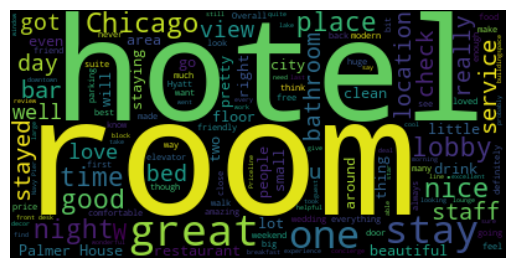

```python
#Positive Reviews Word Cloud
wc_positive = WordCloud(stopwords=STOPWORDS).generate(" ".join(df_pos["reviewContent"]))
plt.imshow(wc_positive, interpolation='bilinear')
plt.axis("off")
plt.show()
```

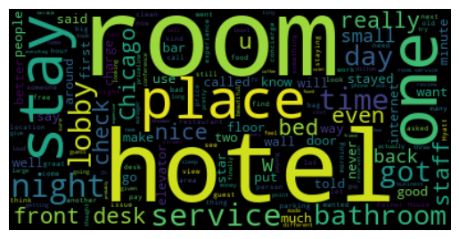

```python
#Negative Reviews Word Cloud
wc_negative = WordCloud(stopwords=STOPWORDS).generate(" ".join(df_neg["reviewContent"]))
plt.imshow(wc_negative, interpolation='bilinear')
plt.axis("off")
plt.show()
```

#### Step 3 - Vectorize Text/Create gensim Dictionary

```python
#Create gensim dictionary with tokens and ids (map frequency of unique words to ids)
dictionary = Dictionary(df["text_tokenized"])
dictionary_pos = Dictionary(df_pos["text_tokenized"])
dictionary_neg = Dictionary(df_neg["text_tokenized"])
```

```python
#Filter dictionary to keep only terms found in at least 20% and no more than 80% of documents
dictionary.filter_extremes(no_below=0.2, no_above=0.8)
dictionary_pos.filter_extremes(no_below=0.2, no_above=0.8)
dictionary_neg.filter_extremes(no_below=0.2, no_above=0.8)

#Create gensim corpus (i.e. a doc-term matrix), uses bag of words with token ids and tf
gensim_corpus = [dictionary.doc2bow(doc) for doc in df["text_tokenized"]]
gensim_corpus_pos = [dictionary_pos.doc2bow(doc) for doc in df_pos["text_tokenized"]]
gensim_corpus_neg = [dictionary_neg.doc2bow(doc) for doc in df_neg["text_tokenized"]]
```

#### Step 4 - Instantiate LDA with Parameters and Fit Model

```python
#Hyperparameter Tuning
for each in range(2, 11):
    ldamodel = LdaModel(corpus = gensim_corpus,
                   num_topics = each,
                   id2word = dictionary,
                   random_state = 757)
    coh = CoherenceModel(model = ldamodel,
                    texts = df["text_tokenized"],
                    dictionary = dictionary,
                    coherence = 'c_v')
    print(f"With {each} topics, Coherence: {coh.get_coherence()}")
```

```
With 2 topics, Coherence: 0.29255399065431287
With 3 topics, Coherence: 0.2939077414848615
With 4 topics, Coherence: 0.29357909467671833
With 5 topics, Coherence: 0.2872395550962198
With 6 topics, Coherence: 0.2873522208997395
With 7 topics, Coherence: 0.27827586678456295
With 8 topics, Coherence: 0.28827553059407385
With 9 topics, Coherence: 0.2821442862984622
With 10 topics, Coherence: 0.2834188874178979
```

```python
#Hyperparameter Tuning (Pos)
for each in range(2, 11):
    ldamodel_pos = LdaModel(corpus = gensim_corpus_pos,
                   num_topics = each,
                   id2word = dictionary_pos,
                   random_state = 757)
    coh = CoherenceModel(model = ldamodel_pos,
                    texts = df_pos["text_tokenized"],
                    dictionary = dictionary_pos,
                    coherence = 'c_v')
    print(f"With {each} topics, Positive Coherence: {coh.get_coherence()}")
```

```
With 2 topics, Positive Coherence: 0.28452274937777644
With 3 topics, Positive Coherence: 0.2747135513002285
With 4 topics, Positive Coherence: 0.27688995084777346
With 5 topics, Positive Coherence: 0.2696631829685471
With 6 topics, Positive Coherence: 0.2741348956203468
With 7 topics, Positive Coherence: 0.27325501395481533
With 8 topics, Positive Coherence: 0.270510045436143
With 9 topics, Positive Coherence: 0.2626201426612113
With 10 topics, Positive Coherence: 0.2724578777196308
```

```python
#Hyperparameter Tuning (Neg)
for each in range(2, 11):
    ldamodel_neg = LdaModel(corpus = gensim_corpus_neg,
                   num_topics = each,
                   id2word = dictionary_neg,
                   random_state = 757)
    coh = CoherenceModel(model = ldamodel_neg,
                    texts = df_neg["text_tokenized"],
                    dictionary = dictionary_neg,
                    coherence = 'c_v')
    print(f"With {each} topics, Negative Coherence: {coh.get_coherence()}")
```

```
With 2 topics, Negative Coherence: 0.18419978352107863
With 3 topics, Negative Coherence: 0.19180089714288803
With 4 topics, Negative Coherence: 0.18941493516619778
With 5 topics, Negative Coherence: 0.1970273298913129
With 6 topics, Negative Coherence: 0.2155575238682085
With 7 topics, Negative Coherence: 0.22688131183882376
With 8 topics, Negative Coherence: 0.23067847936759117
With 9 topics, Negative Coherence: 0.22271568547081624
With 10 topics, Negative Coherence: 0.21330077503002998
```

```python
#Fit model
ldamodel = LdaModel(corpus = gensim_corpus,
                   num_topics = 3,
                   id2word = dictionary,
                   random_state = 757)

ldamodel_pos = LdaModel(corpus = gensim_corpus_pos,
                   num_topics = 2,
                   id2word = dictionary_pos,
                   random_state = 757)

ldamodel_neg = LdaModel(corpus = gensim_corpus_neg,
                   num_topics = 8,
                   id2word = dictionary_neg,
                   random_state = 757)
```

#### Step 5 - View Topics and Results

```python
#Weights (overall)
for top_id, topic in ldamodel.print_topics(num_topics=3, num_words=20):
    print(f"Topic Number (weight*term) {top_id+1}\n \
    {topic}")
```

```
Topic Number (weight*term) 1
     0.009*"one" + 0.009*"great" + 0.007*"would" + 0.006*"nice" + 0.006*"rooms" + 0.006*"chicago" + 0.006*"get" + 0.005*"lobby" + 0.005*"place" + 0.005*"service" + 0.005*"night" + 0.005*"location" + 0.004*"also" + 0.004*"good" + 0.004*"w" + 0.004*"like" + 0.004*"staff" + 0.004*"time" + 0.004*"really…
Topic Number (weight*term) 2
     0.010*"rooms" + 0.008*"lobby" + 0.008*"nice" + 0.007*"like" + 0.006*"chicago" + 0.006*"get" + 0.005*"great" + 0.005*"night" + 0.005*"really" + 0.005*"would" + 0.005*"bar" + 0.005*"place" + 0.005*"service" + 0.004*"one" + 0.004*"good" + 0.004*"time" + 0.004*"also" + 0.004*"small" + 0.004*"staff"…
Topic Number (weight*term) 3
     0.009*"great" + 0.007*"get" + 0.007*"like" + 0.007*"service" + 0.006*"got" + 0.006*"good" + 0.006*"night" + 0.005*"chicago" + 0.005*"location" + 0.005*"would" + 0.005*"w" + 0.005*"nice" + 0.005*"rooms" + 0.005*"time" + 0.005*"bed" + 0.005*"place" + 0.005*"really" + 0.005*"one" + 0.005*"bar" + 0…
```

```python
#Weights (positive)
for top_id, topic in ldamodel_pos.print_topics(num_topics=2, num_words=20):
    print(f"Topic Number (weight*term) {top_id+1}\n \
    {topic}")
```

```
Topic Number (weight*term) 1
     0.009*"great" + 0.008*"nice" + 0.007*"one" + 0.007*"rooms" + 0.006*"w" + 0.005*"chicago" + 0.005*"lobby" + 0.005*"staff" + 0.005*"night" + 0.005*"location" + 0.005*"also" + 0.005*"good" + 0.005*"view" + 0.005*"would" + 0.004*"service" + 0.004*"place" + 0.004*"time" + 0.004*"get" + 0.004*"check"…
Topic Number (weight*term) 2
     0.012*"great" + 0.008*"chicago" + 0.008*"like" + 0.008*"get" + 0.007*"rooms" + 0.007*"lobby" + 0.006*"bar" + 0.006*"good" + 0.005*"service" + 0.005*"nice" + 0.005*"really" + 0.005*"one" + 0.005*"place" + 0.005*"time" + 0.005*"location" + 0.004*"would" + 0.004*"night" + 0.004*"got" + 0.004*"floo…
```

```python
#Weights (negative)
for top_id, topic in ldamodel_neg.print_topics(num_topics=8, num_words=20):
    print(f"Topic Number (weight*term) {top_id+1}\n \
    {topic}")
```

```
Topic Number (weight*term) 1
     0.007*"service" + 0.006*"like" + 0.006*"night" + 0.006*"get" + 0.005*"house" + 0.005*"bed" + 0.005*"would" + 0.005*"place" + 0.005*"rooms" + 0.004*"nice" + 0.004*"lobby" + 0.004*"palmer" + 0.004*"internet" + 0.003*"really" + 0.003*"got" + 0.003*"us" + 0.003*"floor" + 0.003*"also" + 0.003*"even"…
Topic Number (weight*term) 2
     0.008*"would" + 0.007*"desk" + 0.007*"bed" + 0.007*"front" + 0.005*"one" + 0.005*"called" + 0.005*"service" + 0.005*"day" + 0.005*"night" + 0.005*"check" + 0.004*"get" + 0.004*"better" + 0.004*"back" + 0.004*"got" + 0.004*"chicago" + 0.004*"could" + 0.004*"even" + 0.004*"people" + 0.003*"time" …
Topic Number (weight*term) 3
     0.009*"lobby" + 0.007*"place" + 0.007*"rooms" + 0.007*"night" + 0.006*"one" + 0.006*"would" + 0.006*"service" + 0.005*"really" + 0.005*"could" + 0.005*"us" + 0.004*"even" + 0.004*"front" + 0.004*"get" + 0.004*"desk" + 0.004*"check" + 0.004*"day" + 0.004*"bed" + 0.003*"star" + 0.003*"bathroom" +…
Topic Number (weight*term) 4
     0.008*"get" + 0.007*"staff" + 0.007*"one" + 0.006*"back" + 0.006*"would" + 0.005*"night" + 0.005*"desk" + 0.005*"front" + 0.005*"service" + 0.004*"place" + 0.004*"bed" + 0.004*"time" + 0.004*"even" + 0.004*"day" + 0.004*"like" + 0.003*"really" + 0.003*"never" + 0.003*"lobby" + 0.003*"bar" + 0.0…
Topic Number (weight*term) 5
     0.012*"service" + 0.006*"would" + 0.005*"lobby" + 0.005*"could" + 0.005*"get" + 0.005*"got" + 0.005*"staff" + 0.005*"rooms" + 0.005*"one" + 0.004*"never" + 0.004*"night" + 0.004*"even" + 0.004*"small" + 0.004*"go" + 0.004*"like" + 0.004*"better" + 0.004*"us" + 0.004*"floor" + 0.003*"bathroom" +…
Topic Number (weight*term) 6
     0.008*"get" + 0.007*"one" + 0.007*"like" + 0.006*"place" + 0.006*"chicago" + 0.006*"rooms" + 0.006*"would" + 0.006*"desk" + 0.005*"service" + 0.005*"w" + 0.005*"also" + 0.004*"night" + 0.004*"front" + 0.004*"nice" + 0.004*"small" + 0.004*"much" + 0.004*"check" + 0.004*"really" + 0.004*"staff" +…
Topic Number (weight*term) 7
     0.013*"would" + 0.009*"service" + 0.007*"one" + 0.007*"desk" + 0.006*"night" + 0.006*"front" + 0.006*"time" + 0.005*"back" + 0.005*"us" + 0.005*"check" + 0.005*"like" + 0.005*"place" + 0.004*"called" + 0.004*"got" + 0.004*"told" + 0.004*"minutes" + 0.003*"parking" + 0.003*"never" + 0.003*"could…
Topic Number (weight*term) 8
     0.008*"rooms" + 0.008*"get" + 0.008*"would" + 0.007*"got" + 0.006*"one" + 0.005*"night" + 0.005*"really" + 0.005*"lobby" + 0.004*"service" + 0.004*"place" + 0.004*"bathroom" + 0.004*"good" + 0.004*"bed" + 0.004*"even" + 0.004*"nice" + 0.004*"like" + 0.004*"could" + 0.004*"day" + 0.003*"w" + 0.0…
```

#### Step 6 - Evaluate Model: Topic Coherence

```python
#Coherence with all docs
coh = CoherenceModel(model = ldamodel,
                texts = df["text_tokenized"],
                dictionary = dictionary,
                coherence = 'c_v')
print(f"With 3 topics, Coherence: {coh.get_coherence()}")
```

```
With 3 topics, Coherence: 0.2939077414848615
```

```python
#Coherence with pos docs
coh_pos = CoherenceModel(model = ldamodel_pos,
                texts = df_pos["text_tokenized"],
                dictionary = dictionary_pos,
                coherence = 'c_v')
print(f"With 2 topics, Positive Coherence: {coh_pos.get_coherence()}")
```

```
With 2 topics, Positive Coherence: 0.28452274937777644
```

```python
#Coherence with neg docs
coh_neg = CoherenceModel(model = ldamodel_neg,
                texts = df_neg["text_tokenized"],
                dictionary = dictionary_neg,
                coherence = 'c_v')
print(f"With 8 topics, Negative Coherence: {coh_neg.get_coherence()}")
```

```
With 8 topics, Negative Coherence: 0.23067847936759117
```

#### Step 7 - Visualize Results

```python
pyLDAvis.enable_notebook()
```

```python
vis = gensim_pyvis.prepare(topic_model = ldamodel,
                       corpus = gensim_corpus,
                       dictionary = dictionary)

vis_pos = gensim_pyvis.prepare(topic_model = ldamodel_pos,
                       corpus = gensim_corpus_pos,
                       dictionary = dictionary_pos)

vis_neg = gensim_pyvis.prepare(topic_model = ldamodel_neg,
                       corpus = gensim_corpus_neg,
                       dictionary = dictionary_neg)
```

```python
# pyLDAvis
  # Relevance: relevance is a weighted average of the
#        logarithms of a term's probability
#       and the ratio of a term's probability within a topic
#      to its marginal probability across the corpus
#      (i.e. how relevant is that word to that particular topic)
# Left panel:
    # global view of topic model
    # centers of circle are distance between topics then projected onto two PCA dimensions
    # area of circles is the overall prevalence of the topic in the whole topic model
    # examine how prevalent each topic is (size of bubble)
    # examine how topics relate to each other (overlap or distance)
# Right panel:
    # Bars represent individual terms that are most useful for interpreting selected topic on left
    # Blue bar represents corpus wide frequencies
    # Red bar represents topic-specific frequencies
    # examine the meaning of each topic
vis
```

[interactive chart not shown]

```python
vis_pos
```

[interactive chart not shown]

```python
vis_neg
```

[interactive chart not shown]

#### Extra: Document Proportions

```python
tw = []

for each in range(0, 3):
    terms = ldamodel.get_topic_terms(each, 10)
    tw.append([dictionary[words[0]] for words in terms])

tw_pos = []

for each in range(0, 2):
    terms = ldamodel_pos.get_topic_terms(each, 10)
    tw_pos.append([dictionary_pos[words[0]] for words in terms])

tw_neg = []

for each in range(0, 8):
    terms = ldamodel_neg.get_topic_terms(each, 10)
    tw_neg.append([dictionary_neg[words[0]] for words in terms])
```

```python
# Classify each document by its "top" topic and create new column with topic classification
df["topic"] = [sorted(ldamodel[gensim_corpus][each])[0][0] for each in range(len(df["text_tokenized"]))]
df_pos["topic"] = [sorted(ldamodel_pos[gensim_corpus_pos][each])[0][0] for each in range(len(df_pos["text_tokenized"]))]
df_neg["topic"] = [sorted(ldamodel_neg[gensim_corpus_neg][each])[0][0] for each in range(len(df_neg["text_tokenized"]))]
```

```python
df["topic_name"] = np.where(df["topic"] == 0, "Topic 1",
                           np.where(df["topic"] == 1, "Topic 2",
                                   "Topic 3"))

df_pos["topic_name"] = np.where(df_pos["topic"] == 0, "Topic 1",
                           "Topic 2")

df_neg["topic_name"] = np.where(df_neg["topic"] == 0, "Topic 1",
                           np.where(df_neg["topic"] == 1, "Topic 2",
                                   np.where(df_neg["topic"] == 2, "Topic 3",
                                           np.where(df_neg["topic"] == 3, "Topic 4",
                                                   np.where(df_neg["topic"] == 4, "Topic 5",
                                                           np.where(df_neg["topic"] == 5, "Topic 6",
                                                                   np.where(df_neg["topic"] == 6, "Topic 7",
                                                                           "Topic 8")))))))
```

```python
# Create topic labels for our topics
pd.crosstab(df["topic_name"],
            columns="perc",
            normalize=True)
```

| col_0 topic_name | perc |
| --- | --- |
| Topic 1 | 0.798736 |
| Topic 2 | 0.103267 |
| Topic 3 | 0.097998 |

```python
pd.crosstab(df_pos["topic_name"],
            columns="perc",
            normalize=True)
```

| col_0 topic_name | perc |
| --- | --- |
| Topic 1 | 0.948148 |
| Topic 2 | 0.051852 |

```python
pd.crosstab(df_neg["topic_name"],
            columns="perc",
            normalize=True)
```

| col_0 topic_name | perc |
| --- | --- |
| Topic 1 | 0.202970 |
| Topic 2 | 0.133663 |
| Topic 3 | 0.108911 |
| Topic 4 | 0.108911 |
| Topic 5 | 0.079208 |
| Topic 6 | 0.138614 |
| Topic 7 | 0.094059 |
| Topic 8 | 0.133663 |

```python
# Get top words
tw = []

for each in range(0, 3):
    terms = ldamodel.get_topic_terms(each, 10)
    tw.append([dictionary[words[0]] for words in terms])

# Get top words
tw_pos = []

for each in range(0, 2):
    terms = ldamodel_pos.get_topic_terms(each, 10)
    tw_pos.append([dictionary_pos[words[0]] for words in terms])

# Get top words
tw_neg = []

for each in range(0, 8):
    terms = ldamodel_neg.get_topic_terms(each, 10)
    tw_neg.append([dictionary_neg[words[0]] for words in terms])
```

```python
pd.DataFrame({
    "Topic 1":tw[0],
    "Topic 2":tw[1],
    "Topic 3":tw[2]})
```

|  | Topic 1 | Topic 2 | Topic 3 |
| --- | --- | --- | --- |
| 0 | one | rooms | great |
| 1 | great | lobby | get |
| 2 | would | nice | like |
| 3 | nice | like | service |
| 4 | rooms | chicago | got |
| 5 | chicago | get | good |
| 6 | get | great | night |
| 7 | lobby | night | chicago |
| 8 | place | really | location |
| 9 | service | would | would |

```python
pd.DataFrame({
    "Topic 1":tw_pos[0],
    "Topic 2":tw_pos[1]})
```

|  | Topic 1 | Topic 2 |
| --- | --- | --- |
| 0 | great | great |
| 1 | nice | chicago |
| 2 | one | like |
| 3 | rooms | get |
| 4 | w | rooms |
| 5 | chicago | lobby |
| 6 | lobby | bar |
| 7 | staff | good |
| 8 | night | service |
| 9 | location | nice |

```python
pd.DataFrame({
    "Topic 1":tw_neg[0],
    "Topic 2":tw_neg[1],
    "Topic 3":tw_neg[2],
    "Topic 4":tw_neg[3],
    "Topic 5":tw_neg[4],
    "Topic 6":tw_neg[5],
    "Topic 7":tw_neg[6],
    "Topic 8":tw_neg[7]})
```

|  | Topic 1 | Topic 2 | Topic 3 | Topic 4 | Topic 5 | Topic 6 | Topic 7 | Topic 8 |
| --- | --- | --- | --- | --- | --- | --- | --- | --- |
| 0 | service | would | lobby | get | service | get | would | rooms |
| 1 | like | desk | place | staff | would | one | service | get |
| 2 | night | bed | rooms | one | lobby | like | one | would |
| 3 | get | front | night | back | could | place | desk | got |
| 4 | house | one | one | would | get | chicago | night | one |
| 5 | bed | called | would | night | got | rooms | front | night |
| 6 | would | service | service | desk | staff | would | time | really |
| 7 | place | day | really | front | rooms | desk | back | lobby |
| 8 | rooms | night | could | service | one | service | us | service |
| 9 | nice | check | us | place | never | w | check | place |